# EDS 223: assignment 4

Sofia Ingersoll & Heather Childers

2023-12-8

## Overview

Marine aquaculture has the potential to play an important role in the global food supply as a more sustainable protein option than land-based meat production.[^1] [Gentry et al.](https://www.nature.com/articles/s41559-017-0257-9) mapped the potential for marine aquaculture globally based on multiple constraints, including ship traffic, dissolved oxygen, bottom depth .[^2]

For this assignment, you are tasked with determining which Exclusive Economic Zones (EEZ) on the West Coast of the US are best suited to developing marine aquaculture for several species of oysters.

Based on previous research, we know that oysters needs the following conditions for optimal growth:

- sea surface temperature: 11-30°C
- depth: 0-70 meters below sea level

##### Learning objectives:

- combining vector/raster data
- resampling raster data
- masking raster data
- map algebra

### Data

#### Sea Surface Temperature

We will use average annual sea surface temperature (SST) from the years 2008 to 2012 to characterize the average sea surface temperature within the region. The data we are working with was originally generated from [NOAA’s 5km Daily Global Satellite Sea Surface Temperature Anomaly v3.1](https://coralreefwatch.noaa.gov/product/5km/index_5km_ssta.php).

#### Bathymetry

To characterize the depth of the ocean we will use the [General Bathymetric Chart of the Oceans (GEBCO)](https://www.gebco.net/data_and_products/gridded_bathymetry_data/#area).[^3]

#### Exclusive Economic Zones

We will be designating maritime boundaries using Exclusive Economic Zones off of the west coast of US from [Marineregions.org](https://www.marineregions.org/eez.php).

## Assignment

Below is an outline of the steps you should consider taking to achieve the assignment tasks.

#### Prepare data (5 points)

To start, we need to load all necessary data and make sure it has the coordinate reference system.

- load necessary packages and set path
  - I recommend using the [`here` package](https://here.r-lib.org/)

```r
# Loading libraries
library(sf)
library(tidyverse)
library(terra)
library(here)
library(tmap)
library(stars)
library(raster)
library(here)
library(maptiles)
rm(list = ls())
setwd(here())
```

- read in the shapefile for the West Coast EEZ (`wc_regions_clean.shp`)

```r
# Reading in shapefile
wc_regions_clean <- st_read("data/wc_regions_clean.shp",
                            quiet = TRUE)
# Checking CRS
crs(wc_regions_clean)
```

```
## [1] "GEOGCRS[\"WGS 84\",\n    DATUM[\"World Geodetic System 1984\",\n        ELLIPSOID[\"WGS 84\",6378137,298.257223563,\n            LENGTHUNIT[\"metre\",1]]],\n    PRIMEM[\"Greenwich\",0,\n        ANGLEUNIT[\"degree\",0.0174532925199433]],\n    CS[ellipsoidal,2],\n        AXIS[\"geodetic latitu…
```

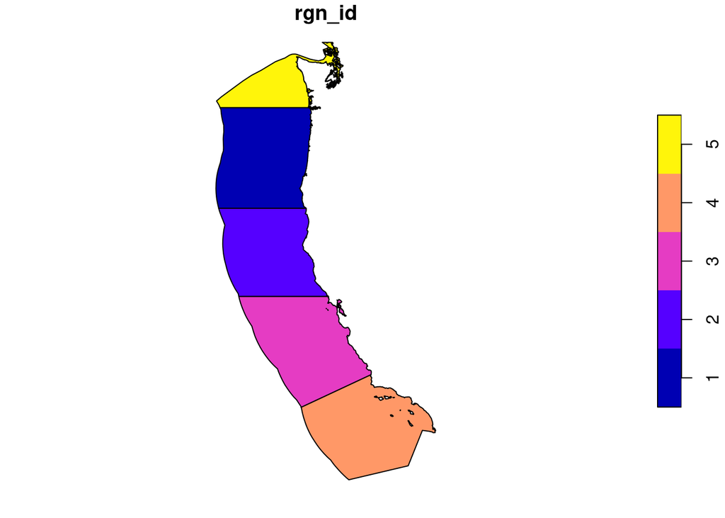

```r
# Visualizing Data
plot(wc_regions_clean["rgn_id"])
```

- read in SST rasters
  - `average_annual_sst_2008.tif`
  - `average_annual_sst_2009.tif`
  - `average_annual_sst_2010.tif`
  - `average_annual_sst_2011.tif`
  - `average_annual_sst_2012.tif`

```r
# Reading in rasters and inspecting CRS
#sst_08 <- read_stars("data/average_annual_sst_2008.tif")
#sst_09 <- read_stars("data/average_annual_sst_2009.tif")
#sst_10 <- read_stars("data/average_annual_sst_2010.tif")
#sst_11 <- read_stars("data/average_annual_sst_2011.tif")
#sst_12 <- read_stars("data/average_annual_sst_2012.tif")

# Checkng CRS, shows evidence of no projection
#st_crs(sst_08)
```

- combine SST rasters into a raster stack

```r
# Combining SST rasters into raster stack

# object tifs names are stored in
files_list <- c("data/average_annual_sst_2008.tif",
                "data/average_annual_sst_2009.tif",
                "data/average_annual_sst_2010.tif",
                "data/average_annual_sst_2011.tif",
                "data/average_annual_sst_2012.tif")
# SpatRaster
sst_stack <- rast(files_list) %>%
  project("EPSG:4326")

# Confirm all tifs in stack and projected correctly
sst_stack
```

```
## class       : SpatRaster
## dimensions  : 480, 408, 5  (nrow, ncol, nlyr)
## resolution  : 0.04165905, 0.04165905  (x, y)
## extent      : -131.9848, -114.9879, 29.99208, 49.98842  (xmin, xmax, ymin, ymax)
## coord. ref. : lon/lat WGS 84 (EPSG:4326)
## source(s)   : memory
## names       : averag~t_2008, averag~t_2009, averag~t_2010, averag~t_2011, averag~t_2012
## min values  :      278.8167,      278.0800,      279.9200,      278.8600,      278.1920
## max values  :      301.4321,      301.4475,      300.9486,      307.2733,      309.8502
```

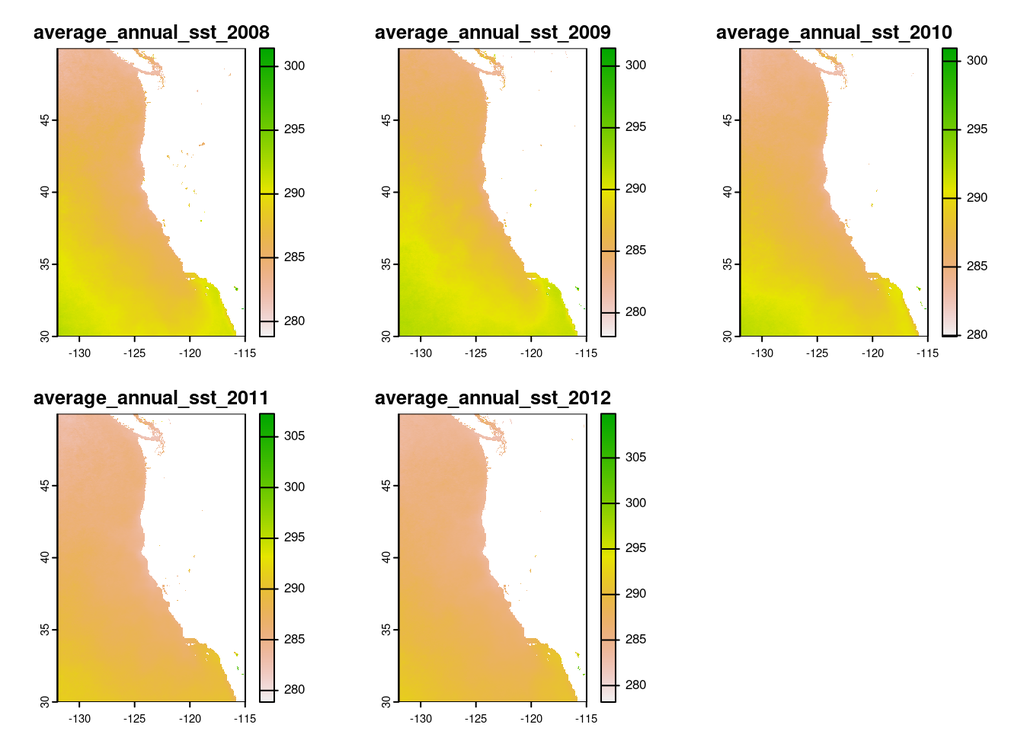

```r
plot(sst_stack)
```

- read in bathymetry raster (`depth.tif`)

```r
# Reading in depth tif spatraster
depth <- read_stars("data/depth.tif")

# Checking crs, we see it's 4326
st_crs(depth)
```

```
## Coordinate Reference System:
##   User input: WGS 84
##   wkt:
## GEOGCRS["WGS 84",
##     DATUM["World Geodetic System 1984",
##         ELLIPSOID["WGS 84",6378137,298.257223563,
##             LENGTHUNIT["metre",1]]],
##     PRIMEM["Greenwich",0,
##         ANGLEUNIT["degree",0.0174532925199433]],
##     CS[ellipsoidal,2],
##         AXIS["geodetic latitude (Lat)",north,
##             ORDER[1],
##             ANGLEUNIT["degree",0.0174532925199433]],
##         AXIS["geodetic longitude (Lon)",east,
##             ORDER[2],
##             ANGLEUNIT["degree",0.0174532925199433]],
##     ID["EPSG",4326]]
```

```
## downsample set to 3
```

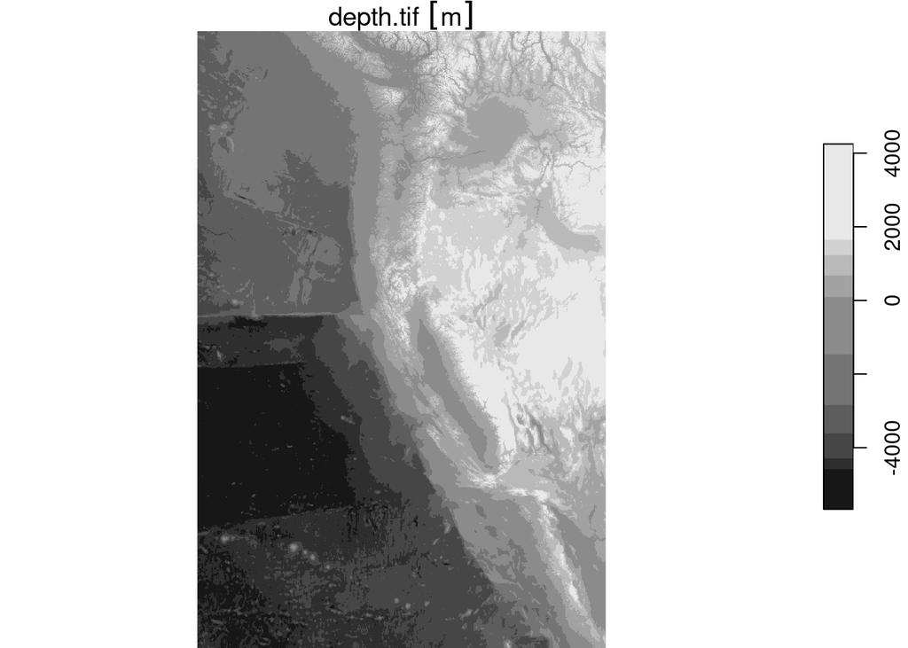

```r
# Visualizing depth shows it's not projecting correctly
plot(depth)
```

```r
# output is NA, provides evidence that this tif is not properly being projected
crs(depth)
```

```
## [1] NA
```

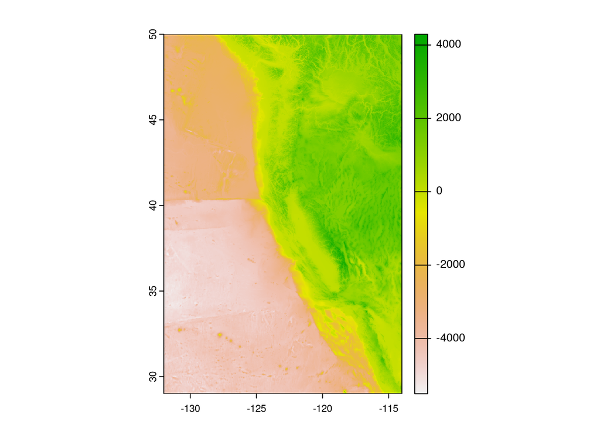

```r
# Projecting CRS
depth <- rast(depth) %>%
 project("EPSG:4326")

# Visualizing depth is now properly projected
plot(depth)
```

- check that data are in the same coordinate reference system
  - reproject any data not in the same projection

```r
# Checking CRS
glimpse(crs(wc_regions_clean))
```

```
##  chr "GEOGCRS[\"WGS 84\",\n    DATUM[\"World Geodetic System 1984\",\n        ELLIPSOID[\"WGS 84\",6378137,298.257223"| __truncated__
```

```r
glimpse(crs(sst_stack))
```

```
##  chr "GEOGCRS[\"WGS 84\",\n    ENSEMBLE[\"World Geodetic System 1984 ensemble\",\n        MEMBER[\"World Geodetic Sys"| __truncated__
```

```r
glimpse(crs(depth))
```

```
##  chr "GEOGCRS[\"WGS 84\",\n    ENSEMBLE[\"World Geodetic System 1984 ensemble\",\n        MEMBER[\"World Geodetic Sys"| __truncated__
```

#### Process data (10 points)

Next, we need process the SST and depth data so that they can be combined. In this case the SST and depth data have slightly different resolutions, extents, and positions. We don’t want to change the underlying depth data, so we will need to resample to match the SST data using the nearest neighbor approach.

- find the mean SST from 2008-2012

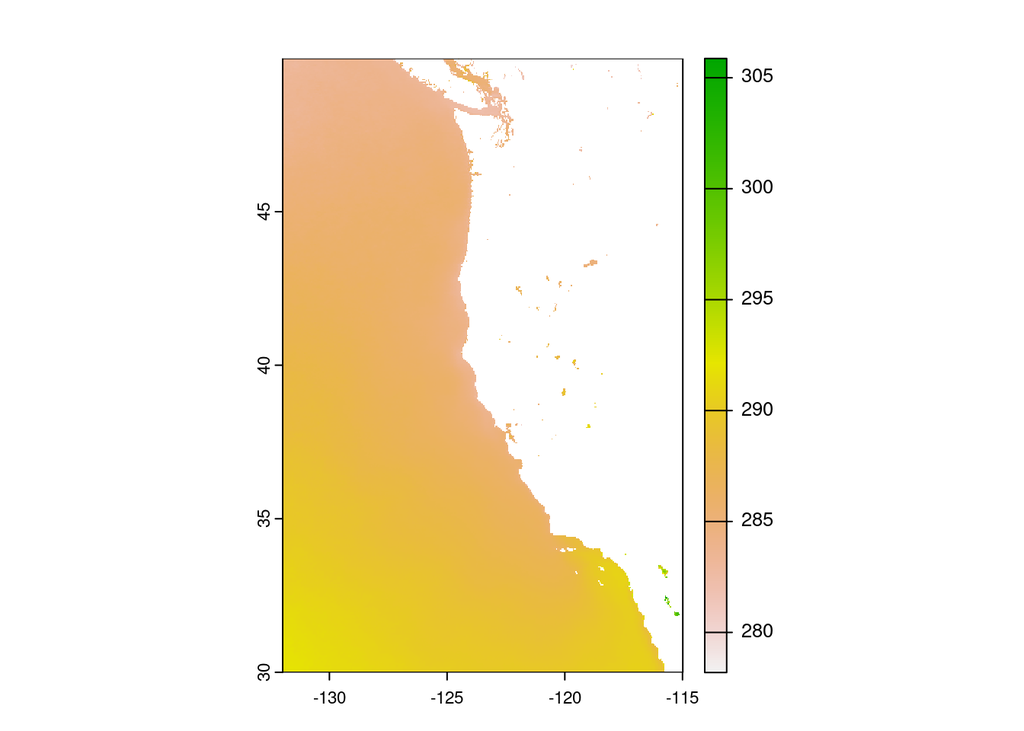

```r
# Finding the mean of the stack layers
mean_sst_stack <- mean(sst_stack, na.rm = TRUE)

plot(mean_sst_stack)
```

- convert SST data from Kelvin to Celsius
  - hint: subtract by 273.15

```r
# Converting from Kelvin to Celcius
mean_sst_stack_c <- mean_sst_stack - 273.15
mean_sst_stack_c
```

```
## class       : SpatRaster
## dimensions  : 480, 408, 1  (nrow, ncol, nlyr)
## resolution  : 0.04165905, 0.04165905  (x, y)
## extent      : -131.9848, -114.9879, 29.99208, 49.98842  (xmin, xmax, ymin, ymax)
## coord. ref. : lon/lat WGS 84 (EPSG:4326)
## source(s)   : memory
## name        :      mean
## min value   :  5.041986
## max value   : 32.720087
```

- crop depth raster to match the extent of the SST raster
  - note: the resolutions of the SST and depth data do not match

```r
depth
```

```
## class       : SpatRaster
## dimensions  : 5040, 4320, 1  (nrow, ncol, nlyr)
## resolution  : 0.004166667, 0.004166667  (x, y)
## extent      : -132, -114, 29, 50  (xmin, xmax, ymin, ymax)
## coord. ref. : lon/lat WGS 84 (EPSG:4326)
## source(s)   : memory
## name        : depth.tif
## min value   :     -7053
## max value   :      4336
```

- resample the NPP data to match the resolution of the SST data using the nearest neighbor approach

```r
# resampling depth to match mean_sst_stack resolution using nearest nbr
depth_resampled <- resample(depth, mean_sst_stack_c, method = "near")

# boolean test to see if resolutions match
resolution(depth_resampled) == resolution(mean_sst_stack_c)
```

```
## [1] TRUE
```

- check that the depth and SST match in resolution, extent, and coordinate reference system
  - hint: can the rasters be stacked?

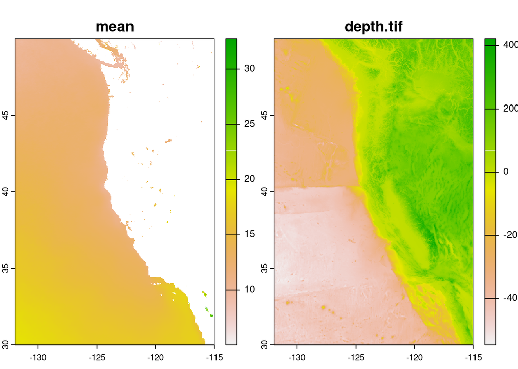

```r
# confirming last step successful with stack
depth_sst <- c(mean_sst_stack_c, depth_resampled)

# plot not successful yet
plot(depth_sst)
```

#### Find suitable locations (20)

In order to find suitable locations for marine aquaculture, we’ll need to find locations that are suitable in terms of both SST and depth.

- reclassify SST and depth data into locations that are suitable for oysters
  - hint: set suitable values to `1` and unsuitable values to `NA`

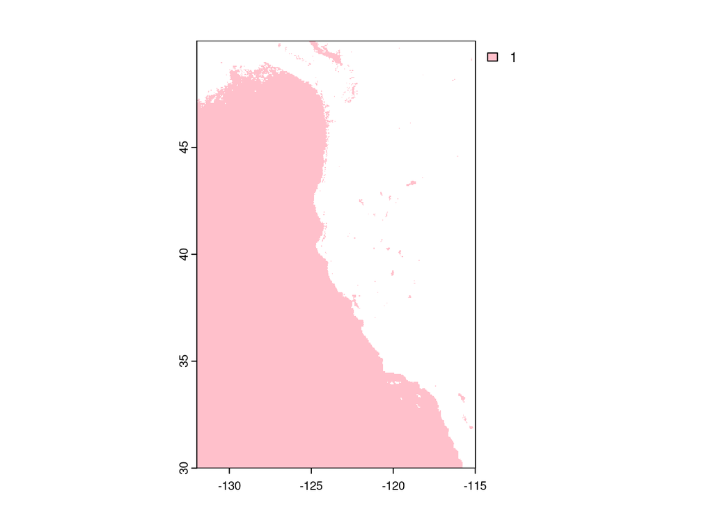

```r
# SST oyster locations
# reclassification matrix: binary raster where sst 11:30 degrees C = 1 (only show oyster friendly areas_)
rcl <- matrix(c(-Inf, 11, NA,
                11, 30, 1,
                30, Inf, NA),
              ncol = 3,
              byrow = TRUE)

# reclassify tif
rcl_sst <- classify(mean_sst_stack_c, rcl = rcl)

# visualize
plot(rcl_sst,
     col = "pink")
```

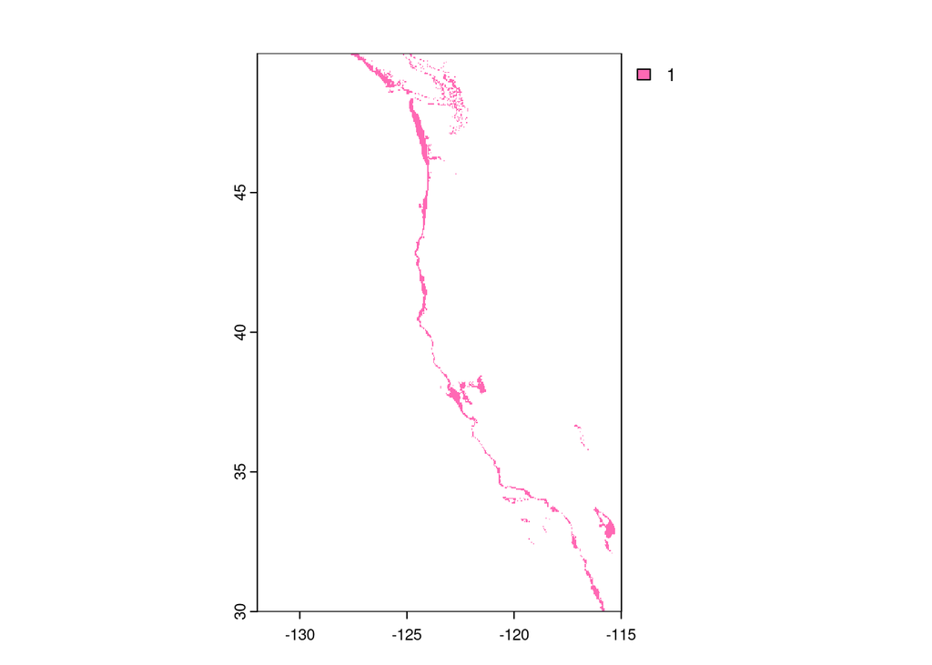

```r
# depth oyster locations
# reclassification matrix: binary raster where sst 0:70 ft C = 1 (only show oyster friendly areas)
rcl2 <- matrix(c(-Inf, -70, NA,
                 -70, 0, 1,
                 0, Inf, NA),
              ncol = 3,
              byrow = TRUE)

# reclassify depth tif to only show oyster friendly areas
rcl_depth <- classify(depth_resampled, rcl = rcl2)

plot(rcl_depth,
     col = 'hotpink')
```

- find locations that satisfy both SST and depth conditions
  - hint: create an overlay using the `lapp()` function multiplying cell values

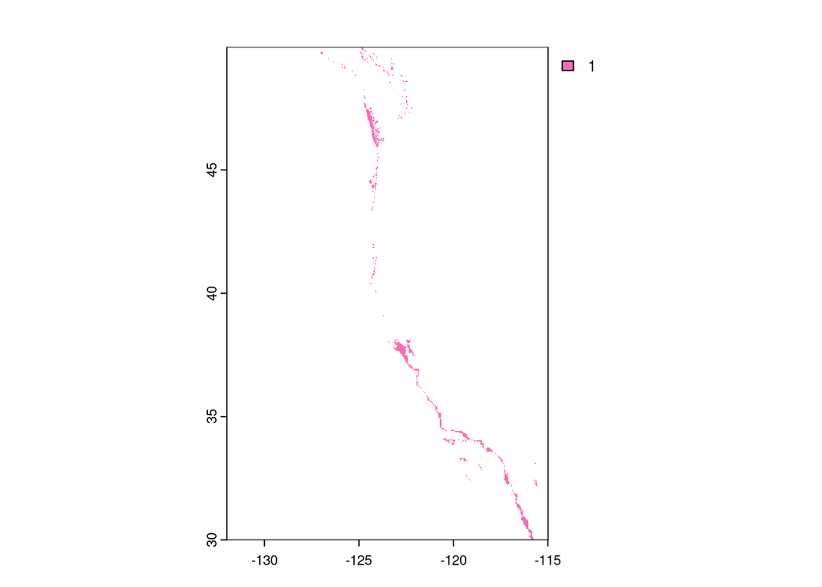

```r
# creating a function to multiply cell values
fun = function(x,y) {
  return(x*y)
}

# creating a spatraster overlay by multiplying raster cell values
oyster_homes <- lapp(c(rcl_sst, rcl_depth),
                     fun = fun)
# visualize
plot(oyster_homes,
     col = 'hotpink')
```

```r
# Check that all values in oyster mask are either 1 or NA
if (
  all(
    unique(oyster_homes) %in% c(1, NA)
  )
)
{
  print("Cool beans! The code ran successfully: our mask only contains values of 1 and NA.")
} else {
  stop("Uh oh! There's an error in the code: our mask contains values other than 1 or NA.")
}
```

```
## [1] "Cool beans! The code ran successfully: our mask only contains values of 1 and NA."
```

#### Determine the most suitable EEZ (20 points)

We want to determine the total suitable area within each EEZ in order to rank zones by priority. To do so, we need to find the total area of suitable locations within each EEZ.

- select suitable cells within West Coast EEZs
- find the total suitable area within each EEZ
  - hint: it might be helpful to rasterize the EEZ data

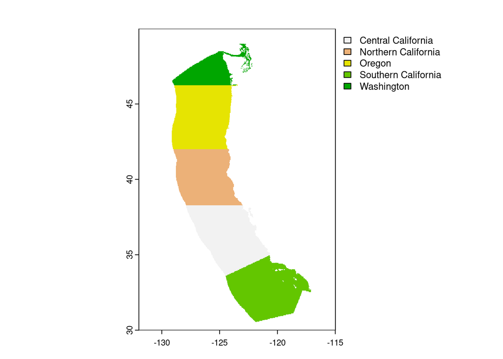

```r
# rasterize wc region data
eez <- rasterize(x = wc_regions_clean,
                 y = mean_sst_stack_c,
                 field = 'rgn')                   # field to rasterize by rgn
# quick visual check
plot(eez)
```

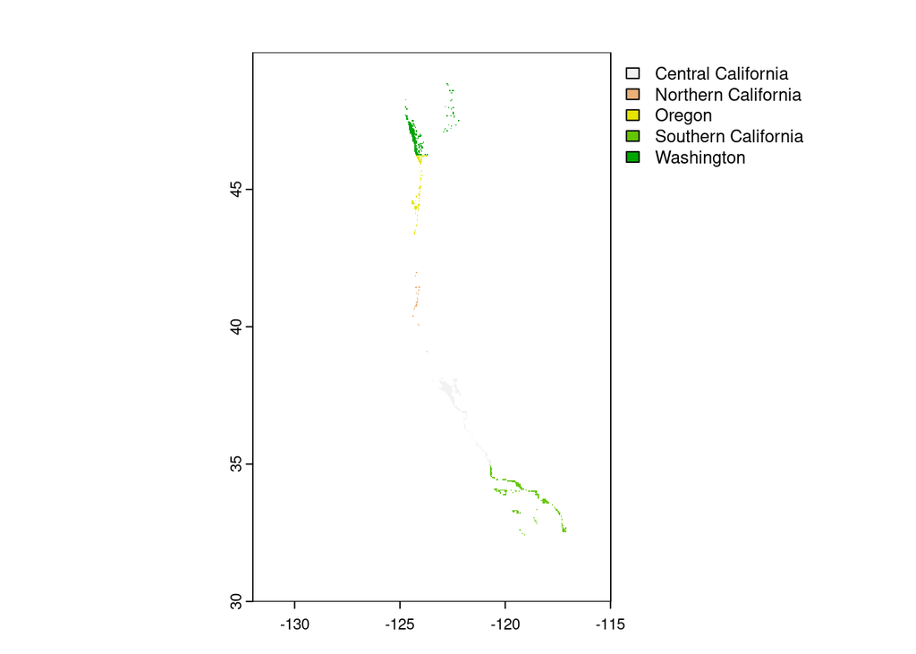

```r
# make a mask
oyster_mask <- mask(eez, oyster_homes)

# cropped vector data
EEZ <- crop(oyster_mask, eez)

# Somethings not working right here
plot(EEZ)
```

- find area of grid cells

```r
# area of grid cells of west coast regions
cell_area <- cellSize(eez)

# calculate west coast areain rgns total area
eez_zonal_stats <- zonal(cell_area,
                         eez,
                         fun = 'sum',
                         na.rm = TRUE)
# check
eez_zonal_stats
```

```
##                   rgn         area
## 1  Central California 202760086375
## 2 Northern California 163746315273
## 3              Oregon 179848499217
## 4 Southern California 206587813072
## 5          Washington  67827380913
```

```r
# cell size of suitable areas in wcr
EEZ_cell_area <- cellSize(EEZ)

# calculate west coast areain rgns
EEZ_zonal_stats <- zonal(EEZ_cell_area,
                         EEZ,
                         fun = 'sum',
                         na.rm = TRUE)
# check
EEZ_zonal_stats
```

```
##                   rgn       area
## 1  Central California 4939798974
## 2 Northern California  438148214
## 3              Oregon 1533072599
## 4 Southern California 3811804815
## 5          Washington 3224686045
```

- find the percentage of each zone that is suitable
- hint it might be helpful to join the suitable area by region onto the EEZ vector data

```r
# find percentage suitable areas
# creating a column for percent of suitable areas zonal stats
zonal_stats <- EEZ_zonal_stats %>%
  rename(suitable_area_m2 = area) %>%
  add_column(eez_zonal_stats$area) %>%
  rename(total_area_m2 = 'eez_zonal_stats$area') %>%
  mutate(pct_suitable = ((suitable_area_m2/total_area_m2)*100))

# confirm it did what we wanted
head(zonal_stats)
```

```
##                   rgn suitable_area_m2 total_area_m2 pct_suitable
## 1  Central California       4939798974  202760086375    2.4362778
## 2 Northern California        438148214  163746315273    0.2675774
## 3              Oregon       1533072599  179848499217    0.8524245
## 4 Southern California       3811804815  206587813072    1.8451257
## 5          Washington       3224686045   67827380913    4.7542541
```

```r
# check calculated percents are 0:100
if (
  any(
    zonal_stats$pct_suitable < 0 | zonal_stats$pct_suitable > 100)
)
{
  stop("Uh oh! There's an error in the code: at least one percent area is not 0:100.")
} else {
  "Cool beans! The code ran successfully: all percents are within the valid range."
}
```

```
## [1] "Cool beans! The code ran successfully: all percents are within the valid range."
```

```r
# rasterize zonal stats & combine w/ og wcr data
zonal_stats_rast <- left_join(wc_regions_clean,
                              zonal_stats,
                              by = 'rgn')
# quick assessment to aid in visual bins
summary(zonal_stats_rast)
```

```
##      rgn              rgn_key             area_m2              rgn_id
##  Length:5           Length:5           Min.   :6.690e+10   Min.   :1
##  Class :character   Class :character   1st Qu.:1.644e+11   1st Qu.:2
##  Mode  :character   Mode  :character   Median :1.800e+11   Median :3
##                                        Mean   :1.642e+11   Mean   :3
##                                        3rd Qu.:2.027e+11   3rd Qu.:4
##                                        Max.   :2.069e+11   Max.   :5
##     area_km2      suitable_area_m2    total_area_m2        pct_suitable
##  Min.   : 66898   Min.   :4.381e+08   Min.   :6.783e+10   Min.   :0.2676
##  1st Qu.:164379   1st Qu.:1.533e+09   1st Qu.:1.637e+11   1st Qu.:0.8524
##  Median :179994   Median :3.225e+09   Median :1.798e+11   Median :1.8451
##  Mean   :164174   Mean   :2.790e+09   Mean   :1.642e+11   Mean   :2.0311
##  3rd Qu.:202738   3rd Qu.:3.812e+09   3rd Qu.:2.028e+11   3rd Qu.:2.4363
##  Max.   :206861   Max.   :4.940e+09   Max.   :2.066e+11   Max.   :4.7543
##           geometry
##  MULTIPOLYGON :5
##  epsg:4326    :0
##  +proj=long...:0
##
##
##
```

#### Visualize results (5 points)

Now that we have results, we need to present them!

Create the following maps:

- total suitable area by region
- percent suitable area by region

Include:

- legible legends
- updated color aesthetics
- basemap

### Map of Suitable Areas for Oysters in West Coast Region, USA (m2)

```r
tmap_mode('plot')
```

```
## tmap mode set to 'plot'
```

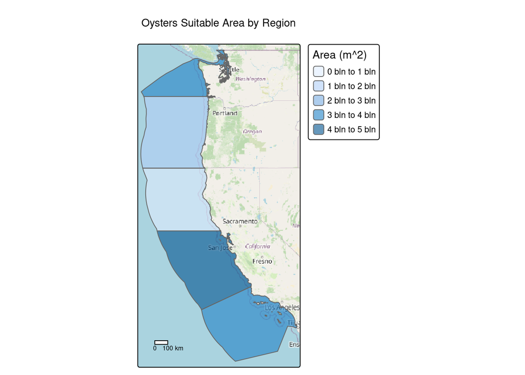

```r
#Create a map to plot the suitable area in m^2
tm_shape(zonal_stats_rast) +
  tm_polygons(fill = 'suitable_area_m2',
              fill_alpha = 0.6,
              fill.scale = tm_scale(breaks = c(0,1.0e+9,2.0e+9,3.0e+9,4.0e+9,5.0e+9)),
              fill.palette = 'Red-Purple',                                             # bins
              fill.legend = tm_legend(title = 'Area (m^2)')) +    # Add legend title
  tm_title(text = 'Oysters Suitable Area by Region') +                     # Add figure title
  tm_scalebar(position = c('left','bottom')) +                             # Add a scalebar
  tm_basemap(server = 'OpenStreetMap')                                     # Add a basemap
```

### Percent of Suitable Areas for Oysters in West Coast Region, USA

```r
# initiate tmap plottings
tmap_mode('plot')
```

```
## tmap mode set to 'plot'
```

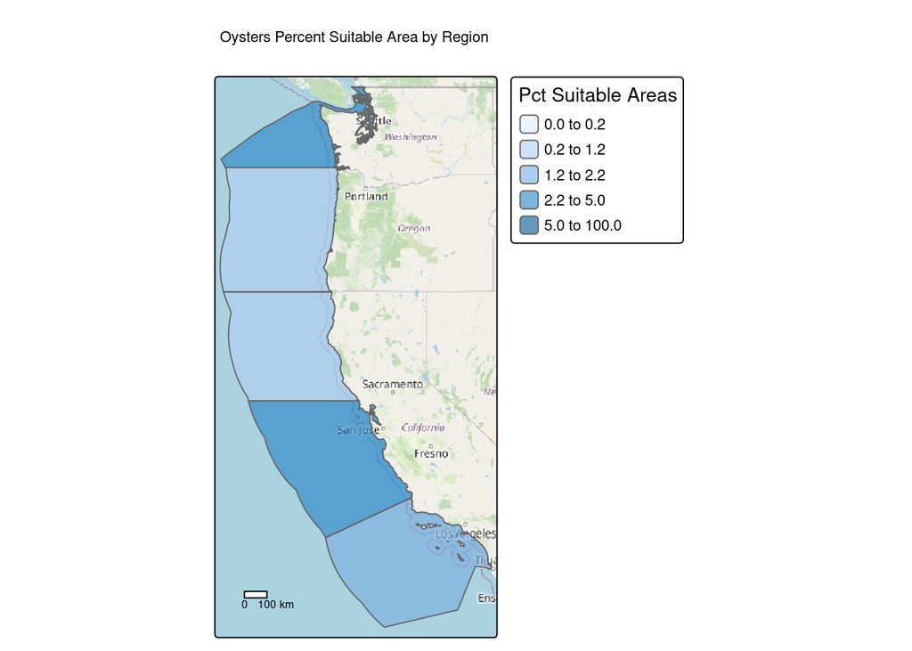

```r
#Create a map to plot the percent of suitable area
tm_shape(zonal_stats_rast) +
  tm_polygons(fill = 'pct_suitable',
              fill_alpha = 0.6,
              values = 'SunsetDark',
              fill.scale = tm_scale(breaks = c(0, 0.25, 1.25, 2.25, 5, 100)), # bins
              fill.legend = tm_legend(title = 'Pct Suitable Areas')) +
  tm_title(text = 'Oysters Percent Suitable Area by Region') +
  tm_scalebar(position = c('left','bottom')) +
  tm_basemap(server = 'OpenStreetMap')
```

```r
# Add polygons w/ colors associated w/ percent suitable areas
# Add legend title
# Add figure title
# Add geometry and opacity
# Add breaks, and legend title
# Add a scalebar
# Add a basemap
```

#### Broaden your workflow! (40 points)

Now that you’ve worked through the solution for one group of species, let’s update your workflow to work for other species. Please create a function that would allow you to reproduce your results for other species. Your function should be able to do the following:

- accept temperature and depth ranges and species name as inputs
- create maps of total suitable area and percent suitable area per EEZ with the species name in the title

```
## tmap mode set to 'plot'
```

```
## Deprecated tmap v3 code detected. Code translated to v4
```

```
## tmap mode set to 'plot'
```

[figure not shown]

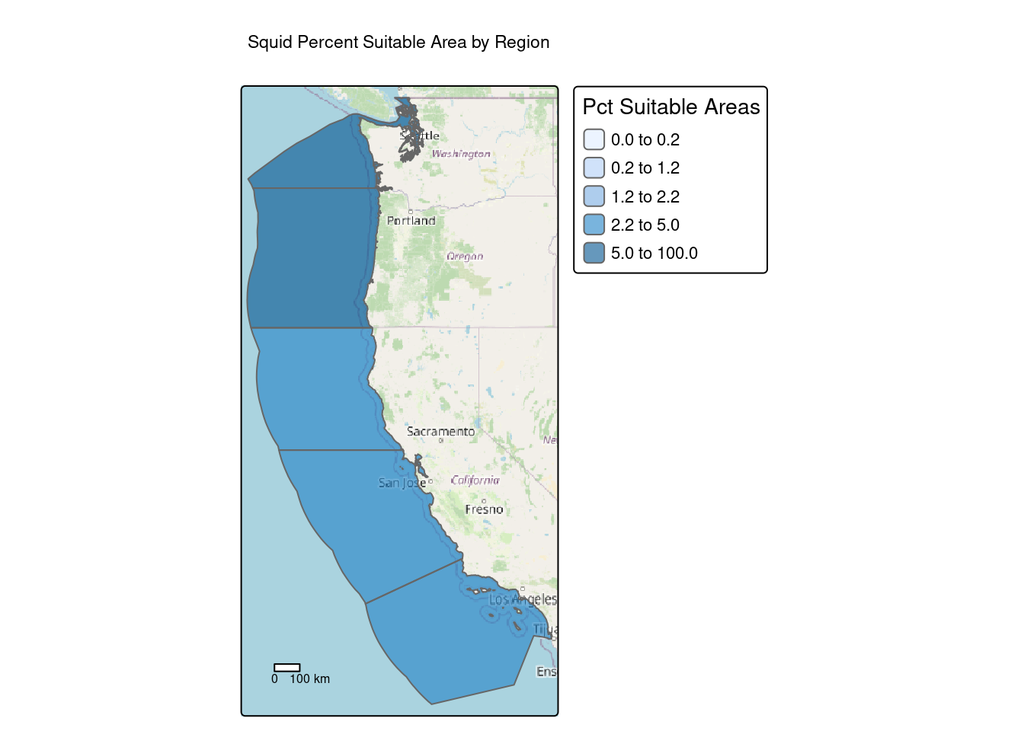

```r
# streamlined function for any species
species_total_suitable_areas <- function(temp_min, temp_max, depth_min, depth_max) {
  # vectorize & reclassify data to be within suitable temp & depth range for desired species
  # sea surface temp is first
  rcl_temp <- matrix(
    c(-Inf, temp_min, NA,
      temp_min, temp_max, 1,
      temp_max, Inf, NA),
    ncol = 3,
    byrow = TRUE)

  sst_species <- classify(mean_sst_stack_c,
                           rcl = rcl_temp)
  # now the same for depth
  rcl_depth <- matrix(
    c(-Inf, depth_min, NA,
      depth_min, depth_max, 1,
      depth_max, Inf, NA),
    ncol = 3,
    byrow = TRUE)

  depth_species <- classify(depth_resampled,
                             rcl = rcl_depth)
  # overlay the spatrasters
  species_homes <<- lapp(c(sst_species, depth_species),
                        fun = fun)

  # rasterize wc region data
  eez <<- rasterize(x = wc_regions_clean,
                    y = mean_sst_stack_c,
                    field = 'rgn')                   # field to rasterize by rgn

   # make a mask
  species_mask <- mask(eez, species_homes)

  species_cropped <<- crop(species_mask, eez)

 # area of grid cells of west coast regions
  cell_area <<- cellSize(eez)

  # calculate west coast area in rgns total area
  eez_zonal_stats <<- zonal(cell_area,
                            eez,
                            fun = 'sum',
                            na.rm = TRUE)
  # total suitable cell area
  suitable_cell_area <<- cellSize(species_cropped)

  # calculate west coast areain rgns total area
  suitable_zonal_stats <<- zonal(suitable_cell_area,
                                 species_cropped,
                                 fun = 'sum',
                                 na.rm = TRUE)

  # find percentage suitable areas
  # creating a column for percent of suitable areas zonal stats
  species_zonal_stats <<- suitable_zonal_stats %>%
    rename(suitable_area_m2 = area) %>%
    add_column(eez_zonal_stats$area) %>%
    rename(total_area_m2 = 'eez_zonal_stats$area') %>%
    mutate(pct_suitable = ((suitable_area_m2/total_area_m2)*100))

  # check calculated percents are 0:100
  if (
    any(
      species_zonal_stats$pct_suitable < 0 | species_zonal_stats$pct_suitable > 100)
  )
  {
    stop("Uh oh! There is an error in the code: at least one percent area is not 0:100.")
  } else {}

  # rasterize zonal stats & combine w/ og wcr data
  species_zonal_stats_rast <<- left_join(wc_regions_clean,
                                species_zonal_stats,
                                by = 'rgn')

  # total suitiable areas map for species of interest (soi)
  tmap_mode("plot")
  total_area_species_map <<- tm_shape(species_zonal_stats_rast) +
    tm_polygons(fill = 'suitable_area_m2',
                fill_alpha = 0.6,
                palette = 'BuPu',
                fill.scale = tm_scale(breaks = c(0,1000000000,2000000000,3000000000,4000000000,5000000000)),               # bins
                fill.legend = tm_legend(title = 'Suitable Area (m^2)')) +    # Add legend title
    tm_title(text = 'Squids Suitable Area by Region') +                      # Add figure title
    tm_scalebar(position = c('left','bottom')) +                             # Add a scalebar
    tm_basemap(server = 'OpenStreetMap')                                     # Add a basemap

  #Create a map to plot the percent of suitable area
  tmap_mode("plot")
  percent_area_species_map <<- tm_shape(species_zonal_stats_rast) +
    tm_polygons(fill = 'pct_suitable',
                fill_alpha = 0.6,
                values = 'SunsetDark',
                fill.scale = tm_scale(breaks = c(0, 0.25, 1.25, 2.25, 5, 100)), # bins
                fill.legend = tm_legend(title = 'Pct Suitable Areas')) +
    tm_title(text = 'Squid Percent Suitable Area by Region') +
    tm_scalebar(position = c('left','bottom')) +
    tm_basemap(server = 'OpenStreetMap')
  # display maps
  return(
    list(total_area_species_map, percent_area_species_map)
  )
}

# return( tmap_arrange(total_area_species_map, percent_area_species_map)

# Run function for species
species_total_suitable_areas(temp_min = 10,
                             temp_max = 16,
                             depth_min = -180,
                             depth_max = -20)
```

Run your function for a species of your choice! You can find information on species depth and temperature requirements on [SeaLifeBase](https://www.sealifebase.ca/search.php). Remember, we are thinking about the potential for marine aquaculture, so these species should have some reasonable potential for commercial consumption.

https://www.sealifebase.ca/Country/CountrySpeciesSummary.php?c_code=840&id=57476

[^1]: Hall, S. J., Delaporte, A., Phillips, M. J., Beveridge, M. & O’Keefe, M. Blue Frontiers: Managing the Environmental Costs of Aquaculture (The WorldFish Center, Penang, Malaysia, 2011).
[^2]: Gentry, R. R., Froehlich, H. E., Grimm, D., Kareiva, P., Parke, M., Rust, M., Gaines, S. D., & Halpern, B. S. Mapping the global potential for marine aquaculture. *Nature Ecology & Evolution*, 1, 1317-1324 (2017).
[^3]: GEBCO Compilation Group (2022) GEBCO_2022 Grid (doi:10.5285/e0f0bb80-ab44-2739-e053-6c86abc0289c).